# Case Study 3 : Textual analysis of movie reviews

```python
print(misclassified_KNeighbors[0][0])
print((misclassified_LinearSVC[0][0]))


print()
print('Review 1. Was actually ' + str(y_test[misclassified_KNeighbors[0][0]]))
print()
print(docs_test_clean[misclassified_KNeighbors[0][0]])
print()
print('Review 2 Was actually ' + str(y_test[misclassified_KNeighbors[0][13]]))
print()
print(docs_test_clean[misclassified_KNeighbors[0][13]])
print()
print('Review 3 Was actually ' + str(y_test[misclassified_LinearSVC[0][0]]))
print()
print(docs_test_clean[misclassified_LinearSVC[0][0]])
print()
print('Review 4 Was actually ' + str(y_test[misclassified_LinearSVC[0][13]]))
print()
print(docs_test_clean[misclassified_LinearSVC[0][13]])
```

```
0
5

Review 1. Was actually 1

the happy bastard's 30-second review :
american pie
the summer of raunch continues to spread into theatres with this latest yuk fest , filled with sick jokes and teen dialogue aplenty .
if you go expecting dawson's creek , you're in for a problem .
if your expectations are lower ( and better , i might add ) , you will enjoy the hell out of american pie .
the movie casts several unknowns , with the only real recognizable one being sctv's own eugene levy as a happy-go-lucky dad .
the story revolves around four high school seniors who have one goal before the school year gets out- get laid .
that's pretty much it .
throughout the movie , little sick comic bits are sprinkled throughout , including a memorable scene involving an apple pie ( i won't give it away , but you probably know what it is ) and an internet broadcast gone horribly awry .
of course , the movie has some slightly sentimental bits , but they don't drag the movie's humor content down that bad .
most of the actors get their job done , but it's levy who's a hoot , a father who tries to talk sex with his son with the help of some curious " visual aids " .
i couldn't stop laughing during this movie , and if you can stand all the raunch and the sex references , then american pie is for you .
if you're one of those " conservative " types , well , i'll bet you're having fun at home while this , south park , and austin powers ii plays in theatres , now aren't you ?


Review 2 Was actually 0

tv's buffy finds herself on the other side of the supernatural spectrum in " simply irresistible . "
sarah michelle gellar , that never-ceasing crusader against never-ending evil every tuesday night on the wb network , here plays a down-on-her-luck chef suspected of dabbling in witchcraft after her flailing restaurant receives help in the form of magically scrumptious meals .
taste test results : some vampire slaying , though out of place , would have really livened this excruciating movie up .
 " simply irresistible " is actually quite easy to deny , a disaster of culinary and other proportions pretty much from the opening on .
gellar's amanda finds herself falling for harried henri bendel exec tom ( sean patrick flannery of powder ) around the same time she discovers an uncanny ability to mystically manifest emotions in her cooking , a secret ingredient that arouses both his interest in her and the public's in her tiny tr…
all this love and sorcery have a lot to do with the telekinetic crab that also figures into the story , a tale that at times plays like an american spin on 1993's mexican classic " like water for chocolate . "
several differences : one , " like water " didn't have a telekinetic crab , and two , " like water " was a good film .
 " simply irresistible , " on the other hand , is about as challenging as an easy-bake oven .
amateurishly staged scenes cancel each other out in their badness , from an embarrassing seduction in a literal vanilla fog to an impromptu dance sequence where tom and amanda do their best fred and ginger - though fred and ginger never took part in anything this garish .
the intrusive musical score distracts from the flat dialogue at regular intervals , but it's not like you're were going to miss much .
in fact , take away the few instances of salty language and this has made-for-disney channel written all over it .
but a majority of " simply irresistible " 's resistibility factor has less to do with the afore-mentioned overkill than the bland leads - tom and amanda are so thin and ambiguously defined that there's just no fun rooting for their inevitable " happily ever after . "
nor do the otherworldly powers that serve to bring them together make sense , so we're left with a ho-hum relationship based on enchanted eclairs ; it's not going to last long , people .
perhaps sensing this , the filmmakers have piled on weird supporting characters for acting vets like betty buckley , dylan baker and patricia clarkson , but they don't go anywhere either .
in fact , nothing in " simply irresistible " goes anywhere save for gellar , and she doesn't go somewhere so much as you wish she'd go _somewhere_ - like to a better movie .
already proving major talent with relatively few big- and small-screen roles , she's the sole reason this overcooked souffle isn't completely fit for the garbage disposal , looking smashing in her todd oldham-designed duds and investing much more in her perfunctory part than she ever gets in return …
it's certainly a dish best not served in it's current condition , but one can only guess that , without gellar , " simply irresistible " would be strictly unwatchable .

```

[output cut: 46 more lines]

```
they are ready to sacrifice their lives .
 " this is a good way to die , " says one of the fallen warriors .
despite the larger-than-life battle sequences , i was unmoved by the entire experience .
at many points , i was even confused .
for example , somewhere in the middle of the film , a sub-plot creeps up involving the prince of the threatened land .
he seems to have an agenda to elevate himself to greater power during this crisis .
however , the sub-plot never fully materializes , and we are left scratching our heads as to the purpose of its inclusion .
there are other questions that i had , but the real problem was that the story ( little of it that there was ) offered no characters to love or hate .
the leader of the viking warriors had the most charisma .
however , banderas's role is completely underwritten and it is unclear why being the 13th warrior makes him so special .
an entire rewrite of the ahmed character is in order .
also , much of the action takes place during torrential downpours or at night , which made battles very difficult to follow .
i would have preferred more time looking at the viking culture and how their beliefs shaped their decision to do battle against the enemy .
as it stands , the film manages more confusion than intensity .
it would make thor cry .
```

```python
import numpy as np
import pandas as pd

def top_tfidf_feats(row, features, top_n=25):
    ''' Get top n tfidf values in row and return them with their corresponding feature names.'''
    topn_ids = np.argsort(row)[::-1][:top_n]
    top_feats = [(features[i], row[i]) for i in topn_ids]
    df = pd.DataFrame(top_feats)
    df.columns = ['feature', 'tfidf']
    return df

def top_feats_in_doc(Xtr, features, row_id, top_n=25):
    ''' Top tfidf features in specific document (matrix row) '''
    row = np.squeeze(Xtr[row_id].toarray())
    return top_tfidf_feats(row, features, top_n)


def top_mean_feats(Xtr, features, grp_ids=None, min_tfidf=0.1, top_n=25):
    ''' Return the top n features that on average are most important amongst documents in rows
        indentified by indices in grp_ids. '''
    if grp_ids:
        D = Xtr[grp_ids].toarray()
    else:
        D = Xtr.toarray()

    D[D < min_tfidf] = 0
    tfidf_means = np.mean(D, axis=0)
    return top_tfidf_feats(tfidf_means, features, top_n)

def top_feats_by_class(Xtr, y, features, min_tfidf=0.1, top_n=25):
    ''' Return a list of dfs, where each df holds top_n features and their mean tfidf value
        calculated across documents with the same class label. '''
    dfs = []
    labels = np.unique(y)
    for label in labels:
        ids = np.where(y==label)
        feats_df = top_mean_feats(Xtr, features, ids, min_tfidf=min_tfidf, top_n=top_n)
        feats_df.label = label
        dfs.append(feats_df)
    return dfs

print("Done")
```

```
Done
```

```python
features = vectorizer.get_feature_names()
top_ngrams = top_feats_by_class(Xtest, y_test, features, min_tfidf=0, top_n=25)
```

```python
import plotly.plotly as py
import plotly.graph_objs as go
import matplotlib.pyplot as plt
from plotly import tools

trace1 = go.Bar(
    y=top_ngrams[0]['feature'],
    x=top_ngrams[0]['tfidf'],
    orientation = 'h',
    name=top_ngrams[0].label
)
trace2 = go.Bar(
    y=top_ngrams[1]['feature'],
    x=top_ngrams[1]['tfidf'],
    orientation = 'h',
    name=top_ngrams[1].label
)




fig = tools.make_subplots(rows=1, cols=2, shared_xaxes=False)

fig.append_trace(trace1, 1,1)
fig.append_trace(trace2, 1, 2)


fig['layout'].update(height=600, width=1000)
offline.iplot(fig, filename = 'plt-1')
```

```
This is the format of your plot grid:
[ (1,1) x1,y1 ]  [ (1,2) x2,y2 ]
```

[interactive chart not shown]

```python
#misclassified_KNeighbors


misclassified_KN_vect = []
actual_y_KN = []
for indx in misclassified_KNeighbors:
    misclassified_KN_vect.append(Xtest[indx])
    actual_y_KN.append(y_test[indx])

misclassified_Linear_vect = []
actual_y_Linear = []
for indx in misclassified_LinearSVC:
    misclassified_Linear_vect.append(Xtest[indx])
    actual_y_Linear.append(y_test[indx])

top_ngrams_mis_kn = top_feats_by_class(misclassified_KN_vect[0], actual_y_KN[0], features, min_tfidf=0, top_n=25)

trace1 = go.Bar(
    y=top_ngrams_mis_kn[0]['feature'],
    x=top_ngrams_mis_kn[0]['tfidf'],
    orientation = 'h',
    name=top_ngrams_mis_kn[0].label
)
trace2 = go.Bar(
    y=top_ngrams_mis_kn[1]['feature'],
    x=top_ngrams_mis_kn[1]['tfidf'],
    orientation = 'h',
    name=top_ngrams_mis_kn[1].label
)




fig = tools.make_subplots(rows=1, cols=2, shared_xaxes=False)

fig.append_trace(trace1, 1,1)
fig.append_trace(trace2, 1, 2)


fig['layout'].update(height=600, width=1000)
offline.iplot(fig, filename = 'plt-2')
```

```
This is the format of your plot grid:
[ (1,1) x1,y1 ]  [ (1,2) x2,y2 ]
```

[interactive chart not shown]

```python
#misclassified_LinearSVC

top_ngrams_mis_Linear = top_feats_by_class(misclassified_Linear_vect[0], actual_y_Linear[0], features, min_tfidf=0, top_n=25)

trace1 = go.Bar(
    y=top_ngrams_mis_Linear[0]['feature'],
    x=top_ngrams_mis_Linear[0]['tfidf'],
    orientation = 'h',
    name=top_ngrams_mis_Linear[0].label
)
trace2 = go.Bar(
    y=top_ngrams_mis_Linear[1]['feature'],
    x=top_ngrams_mis_Linear[1]['tfidf'],
    orientation = 'h',
    name=top_ngrams_mis_Linear[1].label
)




fig = tools.make_subplots(rows=1, cols=2, shared_xaxes=False)

fig.append_trace(trace1, 1,1)
fig.append_trace(trace2, 1, 2)


fig['layout'].update(height=600, width=1000)
offline.iplot(fig, filename = 'plt-6')
```

```
This is the format of your plot grid:
[ (1,1) x1,y1 ]  [ (1,2) x2,y2 ]
```

[interactive chart not shown]

## Problem 4 (20 points): Open Ended Question: Finding the right plot

- Can you find a two dimensional plot in which the positive and negative reviews are separated?
  - This problem is hard since you will likely have thousands of features for review, and you will need to transform these thousands of features into just two numbers (so that you can make a 2D plot).
- Note, I was not able to find such a plot myself!
  - So, this problem is about **trying** but perhaps **not necessarily succeeding**!
- I tried two things, neither of which worked very well.
  - I first plotted the length of the review versus the number of features we compute that are in that review
  - Second I used Principle Component Analysis on a subset of the features.
- Can you do better than I did!?

```python
#manifold learning
```

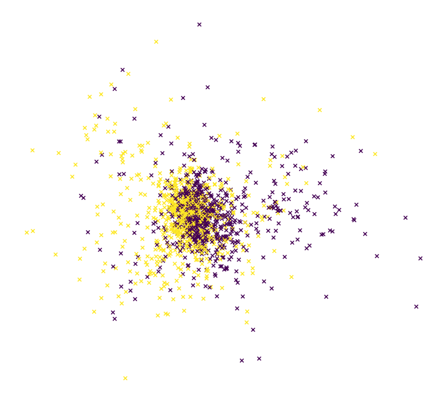

```python
%pylab inline

from sklearn import manifold

import copy

from sklearn.decomposition import TruncatedSVD


docs_train3 = copy.deepcopy(docs_train)
docs_test3 = copy.deepcopy(docs_test)

vectorizer = TfidfVectorizer(min_df=3, max_df=0.95, ngram_range = (1, 3), stop_words='english')

vectorizer.fit(docs_train3)

Xtrain = vectorizer.transform(docs_train3)
Xtest = vectorizer.transform(docs_test3)


X_reduced = TruncatedSVD(n_components=100, random_state=0).fit_transform(Xtrain)

k = 10
d=2

X_embedded = manifold.SpectralEmbedding(n_neighbors = 100).fit_transform(X_reduced)

fig = plt.figure(figsize=(10, 10))
ax = plt.axes(frameon=False)
plt.setp(ax, xticks=(), yticks=())
plt.subplots_adjust(left=0.0, bottom=0.0, right=1.0, top=0.9,
                wspace=0.0, hspace=0.0)
plt.scatter(X_embedded[:, 0], X_embedded[:, 1],
        c=y_train, marker="x")
```

```python
import plotly.plotly as py
import plotly.graph_objs as go

trace1 = go.Scatter(
    x = X_embedded[:, 0],
    y = X_embedded[:, 1],
    mode='markers',
    marker=dict(
        size='6',
        color = y_train, #set color equal to a variable
        colorscale='Viridis',
        showscale=True
    )
)
data = [trace1]

offline.iplot(data, filename='plt-3')
```

[interactive chart not shown]

```python
from textblob import TextBlob

docs_sent = []
for review in docs_train:
    text = review.decode('utf-8')
    analysis = TextBlob(text)
    docs_sent.append(analysis.sentiment.polarity)


rev_len = []

for review in docs_train:
    rev_len.append(len(review))

print("Done!")
```

```
Done!
```

```python
#Sentiment analysis
```

```python
import plotly.plotly as py
import plotly.graph_objs as go

trace1 = go.Scatter(
    x = docs_sent,
    y = rev_len,
    mode='markers',
    marker=dict(
        size='6',
        color = y_train, #set color equal to a variable
        colorscale='Viridis',
        showscale=True
    )
)
data = [trace1]

offline.iplot(data, filename='plt-4')
```

[interactive chart not shown]

```python
from sklearn.decomposition import TruncatedSVD
from sklearn import manifold

import copy

print("Starting!")
docs_train3 = copy.deepcopy(docs_train)
docs_test3 = copy.deepcopy(docs_test)

vectorizer = TfidfVectorizer(min_df=3, max_df=0.95, ngram_range = (1, 3), stop_words='english')

vectorizer.fit(docs_train3)

Xtrain = vectorizer.transform(docs_train3)
Xtest = vectorizer.transform(docs_test3)

print("Reducing!")

X_reduced = TruncatedSVD(n_components=50, random_state=0).fit_transform(Xtrain)

k = 10
d=2

print("Embedding!")

X_embedded = manifold.TSNE(n_components = 12).fit_transform(X_reduced)

print("Done!")
```

```
Starting!
Reducing!
Embedding!
Done!
```

```python
X_embedded
```

```
array([[ 155.70148171,   27.78769997,   88.37068586, ...,  116.8448258 ,
         -85.60952676, -352.43170689],
       [-143.73446491,  -58.53767442, -121.56552747, ...,  -48.99316942,
          85.10478174,  135.50941282],
       [ 139.93019146,  -83.6630866 , -213.48922674, ...,  323.76453241,
          33.07393941,  -82.81568122],
       ...,
       [  69.3473621 ,  131.64406457,  -23.36674176, ...,  139.07843123,
         399.21892682, -176.9324738 ],
       [   8.02475125,  162.62357437,  144.73552258, ..., -425.24340582,
          83.29999342,  182.62332183],
       [ -43.7488445 ,  -53.87448812, -146.7501733 , ..., -110.73305447,
         108.00400109,    1.97767857]])
```

```python
X_embedded
```

```
array([[ 155.70148171,   27.78769997,   88.37068586, ...,  116.8448258 ,
         -85.60952676, -352.43170689],
       [-143.73446491,  -58.53767442, -121.56552747, ...,  -48.99316942,
          85.10478174,  135.50941282],
       [ 139.93019146,  -83.6630866 , -213.48922674, ...,  323.76453241,
          33.07393941,  -82.81568122],
       ...,
       [  69.3473621 ,  131.64406457,  -23.36674176, ...,  139.07843123,
         399.21892682, -176.9324738 ],
       [   8.02475125,  162.62357437,  144.73552258, ..., -425.24340582,
          83.29999342,  182.62332183],
       [ -43.7488445 ,  -53.87448812, -146.7501733 , ..., -110.73305447,
         108.00400109,    1.97767857]])
```

```python
#Parallel coordinates
```

```python
import plotly.plotly as py
import plotly.graph_objs as go

import pandas as pd

df = pd.DataFrame(X_embedded, columns = ['One', 'Two', 'Three', 'Four', 'Five', 'Six', 'Seven', 'Eight', 'Nine', 'Ten', 'Eleven', 'Twelve'])

data = [
    go.Parcoords(
        line = dict(color = y_test),
        dimensions = list([
            dict(range = [-1000,1000],
                constraintrange = [-1000,1000],
                label = 'One', values = df['One']),
            dict(range = [-1000,1000],
                label = 'Two', values = df['Two']),
            dict(range = [-1000,1000],
                label = 'Three', values = df['Three']),
            dict(range = [-1000,1000],
                label = 'Four', values = df['Four']),
            dict(range = [-1000,1000],
                label = 'Five', values = df['Five']),
            dict(range = [-1000,1000],
                label = 'Six', values = df['Six']),
            dict(range = [-1000,1000],
                label = 'Seven', values = df['Seven']),
            dict(range = [-1000,1000],
                label = 'Eight', values = df['Eight']),
            dict(range = [-1000,1000],
                label = 'Nine', values = df['Nine']),
            dict(range = [-1000,1000],
                label = 'Ten', values = df['Ten']),
            dict(range = [-1000,1000],
                label = 'Eleven', values = df['Eleven']),
            dict(range = [-1000,1000],
                label = 'Twelve', values = df['Three'])
        ])
    )
]

layout = go.Layout(
    plot_bgcolor = '#E5E5E5',
    paper_bgcolor = '#E5E5E5'
)

fig = go.Figure(data = data, layout = layout)
py.iplot(fig, filename = 'plt-5')
```

[interactive chart not shown]

```python
from sklearn.decomposition import PCA
import copy

X_train = copy.deepcopy(Xtrain)

pca_proj = PCA(n_components = 2)

X_not_sparse = X_train.toarray()
pca_proj_done = pca_proj.fit_transform(X_not_sparse)

pca_proj_done
```

```
array([[ 0.01593589, -0.02263088],
       [ 0.04865748,  0.0135758 ],
       [-0.02344346,  0.01623661],
       ...,
       [ 0.10867098, -0.02311637],
       [-0.00035896, -0.01287123],
       [-0.06453657,  0.05107165]])
```

```python
pca_proj_done[:, 0]
```

```
array([ 0.01593589,  0.04865748, -0.02344346, ...,  0.10867098,
       -0.00035896, -0.06453657])
```

```python
#PCA
```

```python
trace1 = go.Scatter(
    x = pca_proj_done[:, 0],
    y = pca_proj_done[:, 1],
    mode='markers',
    marker=dict(
        size='6',
        color = y_train, #set color equal to a variable
        colorscale='Viridis',
        showscale=True
    )
)
data = [trace1]

offline.iplot(data, filename='plt-8')
```

[interactive chart not shown]

# Report: communicate the results (20 points)

(1) (5 points) What data you collected?

(2) (5 points) Why this topic is interesting or important to you? (Motivations)

(3) (5 points) How did you analyse the data?

(4) (5 points) What did you find in the data? (please include figures or tables in the report, but no source code)

# Slides (for 10 minutes of presentation) (20 points)

1. (5 points) Motivation about the data collection, why the topic is interesting to you.
2. (10 points) Communicating Results (figure/table)
3. (5 points) Story telling (How all the parts (data, analysis, result) fit together as a story?)

# Done

All set!

**What do you need to submit?**

- **Notebook File**: Save this IPython notebook, and find the notebook file in your folder (for example, "filename.ipynb"). This is the file you need to submit. Please make sure all the plotted tables and figures are in the notebook. If you used "ipython notebook --pylab=inline" to open the notebook, all the figures and tables should have shown up in the notebook.
- **PPT Slides**: please prepare PPT slides (for 10 minutes' talk) to present about the case study . We will ask two teams which are randomly selected to present their case studies in class for this case study.
- **Report**: please prepare a report (less than 10 pages) to report what you found in the data.
  - What is the relationship between this topic and Business Intelligence?
  - How did you analyse the data?
  - What did you find in the data?
  - What conjectures did you make and how did you support or disprove them using data?
  - Did you find anything suprising in the data?
  - What business decision do you think this data could help answer? Why?

    (please include figures or tables in the report, **but no source code**)

*Please compress all the files into a single zipped file.*

**How to submit:**

```
    Please submit through email to Prof. Paffenroth (rcpaffenroth@wpi.edu) *and* the TA Yingnan Liu (yliu18@wpi.edu).
```

#### We auto-process the submissions so make sure your subject line is *exactly*:

### DS501 Case Study 3 Team ??

#### where ?? is your team number.

**Note: Each team just needs to submits one submission**